# Количественный анализ социальных данных с помощью пакета R

Финальное домашнее задание

Павел Дурягин

**Уважаемые Борис и Ольга, хочу предупредить, что мои знания в статистике и программировании пока что практически нулевые (это объясняется моим филологическим образованием), прошу не судить строго! Я стараюсь постепенно разбираться. Большое спасибо за ваш курс, он был очень интересным и полезным для меня. С уважением, Павел Дурягин.**

# Загрузка пакетов

Загружаем пакеты

```r
library(tidyverse)
library(rio)
library(skimr)
library(knitr)
library(ggplot2)
library(stringr)
library(visdat)
library(naniar)
library(corrplot)
library(dplyr)
library(tibble)
library(factoextra)
library(patchwork)
library(broom)
library(lmtest)
library(GGally)
library(caret)
library(FFTrees)
library(margins)
library(rpart.plot)
library(plotROC)
library(ggeffects)
library(MLmetrics)
```

# Наши данные

Импортируем файл с данными, который представляет собой измерение акустических характеристик (длительность, значения формант) 12 гласных английского языка в произношении *45 мужчин, 48 женщин и 46 детей (мальчиков и девочек)*. Измерение было проведено в рамках экспериментального исследования [Hillenbrand, J., Getty, L. A., Clark, M. J., & Wheeler, K. (1995). Acoustic characteristics of American English vowels. Journal of the Acoustical Society of America, 97(5, Pt 1), 3099-3111](https://homepages.wmich.edu/~hillenbr/Papers/HillenbrandGettyClarkWheeler.pdf). Об этом наборе данных я узнал благодаря курсу [“Analyzing the Sounds of Languages”](http://hdl.handle.net/1811/77848)

## Условные обозначения для гласных

##### ae=“had”

##### ah=“hod”

##### aw=“hawed”

##### eh=“head”

##### er=“heard”

##### ei=“haid”

##### ih=“hid”

##### iy=“heed”

##### oa=/o/ as in “boat”

##### oo=“hood”

##### uh=“hud”

##### uw=“who’d”

## Импорт данных

```r
vowels_old <- import("english_vowels.txt", head = TRUE)
```

## Работа с данными. Факторные переменные

Присвоим имена столбцам. Условные обозначения гласных, пол и возрастная группа информантов закодированы в столбце filename. Извлекаем эту информацию в отдельные столбцы. Затем изменяем формат данных из текстовых в факторные.

```r
colnames(vowels_old) <- c("name", "duration", "f0", "f1", "f2", "f3", "f4", "f120", "f220", "f320", "f150", "f250", "f350", "f180", "f280", "f380")
vowels_old <- mutate (vowels_old, gender = str_sub(name, 1, 1), number = str_sub(name, 2,3), vowel = str_sub(name, 4,5))
vowels <- mutate_if(vowels_old, is.character, factor)
head(vowels)
```

```
##    name duration  f0  f1   f2   f3   f4 f120 f220 f320 f150 f250 f350 f180
## 1 m01ae      323 174 663 2012 2659 3691  669 2008 2671  671 1992 2659  685
## 2 m02ae      250 102 628 1871 2477 3489  627 1871 2456  636 1881 2455  628
## 3 m03ae      344  99 605 1812 2570    0  608 1812 2572  618 1789 2618  632
## 4 m04ae      312 124 627 1910 2488 3463  629 1882 2460  720 1750 2435  757
## 5 m06ae      254 115 647 1864 2561 3506  642 1866 2557  666 1829 2499  689
## 6 m07ae      254  96 582 1999 2567 3754  592 1958 2568  624 1925 2569  626
##   f280 f380 gender number vowel
## 1 1773 2680      m     01    ae
## 2 1793 2451      m     02    ae
## 3 1708 2693      m     03    ae
## 4 1563 2527      m     04    ae
## 5 1696 2556      m     06    ae
## 6 1791 2577      m     07    ae
```

## Нулевые значения

Из описательного анализа видно, что некоторые наблюдения, связанные с измерениями формант, указаны как равные нулю. Это невозможно, поэтому я решил заменить “нули” на отсутствующие значения. Визуализируем отсутствующие значения, из этой визуализации видим, что чаще всего отсутствуют измерения третьей и четвертой формант (*пояснение: название столбца, например, f350, означает “Значение третьей форманты в середине (f3 в 50% длительности)”*).

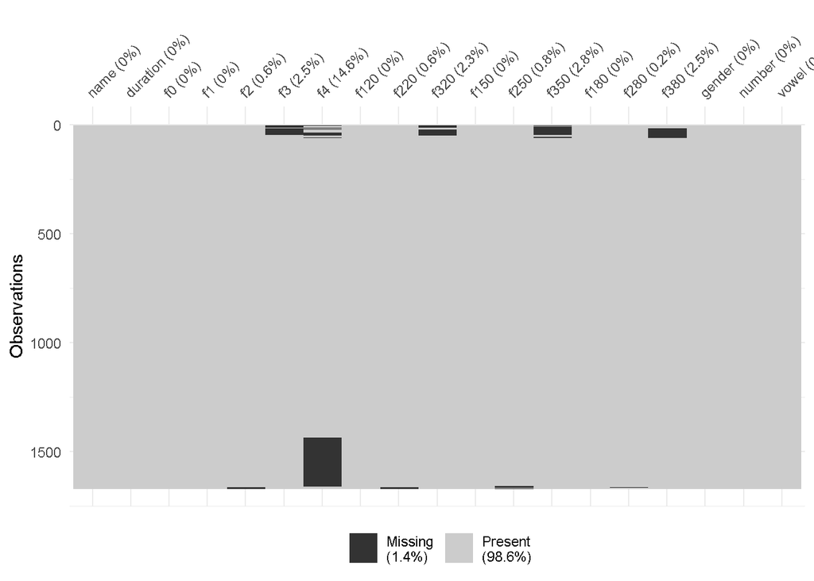

```r
vowels[vowels == 0] <- NA
vis_miss(vowels, cluster = TRUE)
```

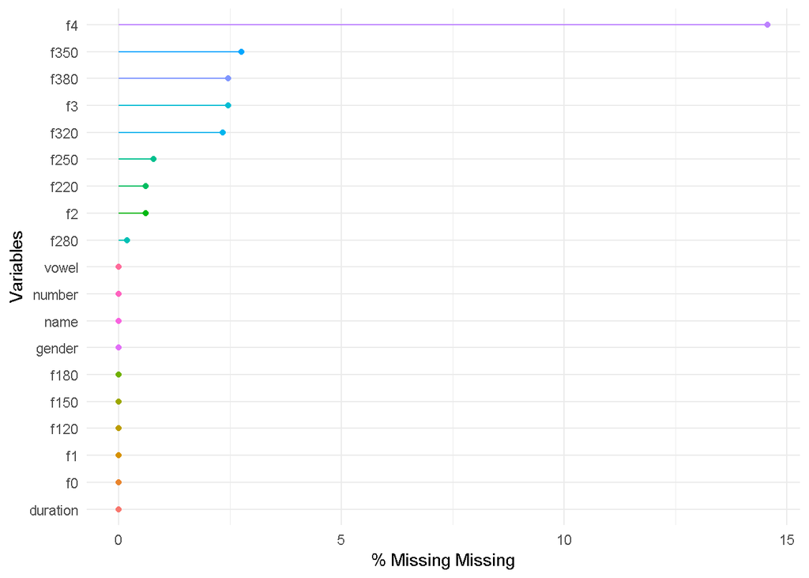

```r
gg_miss_var(vowels, show_pct = TRUE)
```

## Описательный анализ данных

```r
skim(vowels)
```

```
## Skim summary statistics
##  n obs: 1668
##  n variables: 19
##
## Variable type: factor
##  variable missing complete    n n_unique
##    gender       0     1668 1668        4
##      name       0     1668 1668     1668
##    number       0     1668 1668       49
##     vowel       0     1668 1668       12
##                          top_counts ordered
##      w: 576, m: 540, b: 324, g: 228   FALSE
##      b01: 1, b01: 1, b01: 1, b01: 1   FALSE
##      01: 48, 02: 48, 04: 48, 07: 48   FALSE
##  ae: 139, ah: 139, aw: 139, eh: 139   FALSE
##
## Variable type: integer
##  variable missing complete    n    mean     sd   p0     p25    p50     p75
##  duration       0     1668 1668  274.67  64.5   111  227     271    319
##        f0       0     1668 1668  197.03  51.76   90  147     213    236
##        f1       0     1668 1668  597.74 161.8   305  483.75  563.5  693
##      f120       0     1668 1668  601.66 160.16  301  489     569    693
##      f150       0     1668 1668  600.69 166.73  293  474     565    705
##      f180       0     1668 1668  581.04 159.26  271  451.5   552    683
##        f2      10     1658 1668 1743.06 607.19  659 1217.75 1611.5 2253
##      f220      10     1658 1668 1746.02 601.23  788 1226.25 1617   2248
##      f250      13     1655 1668 1751.05 590.24  685 1276.5  1664   2194.5
##      f280       3     1665 1668 1829.5  538.05  664 1484    1797   2146
##        f3      41     1627 1668 2828.65 435.35 1487 2567    2839   3106.5
##      f320      39     1629 1668 2829.28 434.79 1491 2572    2832   3099
##      f350      46     1622 1668 2819.62 428.19 1515 2565.25 2829   3087.75
##      f380      41     1627 1668 2832.5  424.7  1602 2582    2833   3102.5
##        f4     243     1425 1668 4016.76 479.51 2763 3669    4018   4328
##  p100     hist
##   486 ▁▃▇▇▆▃▁▁
##   330 ▃▃▂▃▇▃▁▁
##  1316 ▂▇▆▃▂▁▁▁
##  1333 ▂▇▆▃▂▁▁▁
##  1364 ▂▇▅▃▂▁▁▁
##  1103 ▂▇▇▅▃▂▁▁
##  3451 ▃▇▇▅▅▅▂▁
##  3451 ▆▇▆▅▅▃▁▁
##  3389 ▃▇▇▆▅▃▂▁
##  3395 ▂▃▆▇▅▂▂▁
##  4430 ▁▁▅▇▆▂▁▁
##  4366 ▁▁▅▇▆▂▁▁
##  4447 ▁▁▅▇▅▂▁▁
##  5272 ▁▃▇▅▁▁▁▁
##  5883 ▁▃▆▇▅▁▁▁
```

В таблице данных 19 переменных и 1668 наблюдений. После преобразования мы имеем 4 факторные переменные и 15 целочисленных переменных.

# Строим графики

## Гистограммы

Посмотрим, как распределены по длительности все гласные.

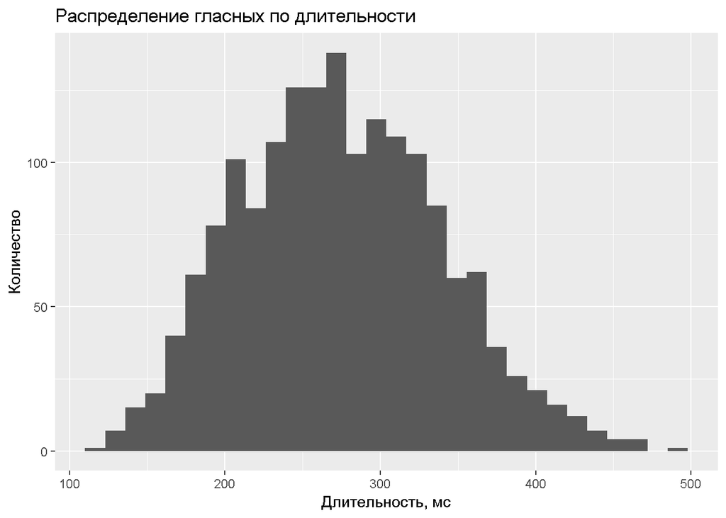

```r
qplot (data = vowels, x = duration) +  labs(x = 'Длительность, мс', y = 'Количество', title = 'Распределение гласных по длительности')
```

## “Ящики с усами” и скрипичные графики для сравнения длительности гласных

Сравним длительность разных гласных с помощью “ящиков с усами”.

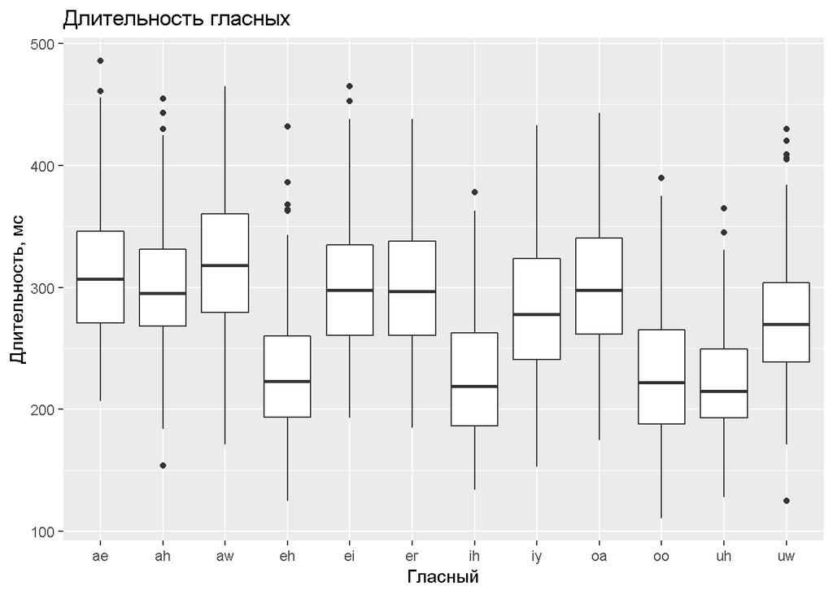

```r
ggplot(data = vowels, aes(x=vowel, y=duration)) + geom_boxplot() + labs(x = 'Гласный', y = 'Длительность, мс', title = 'Длительность гласных')
```

Отдельные графики, например, для мужчин и для женщин.

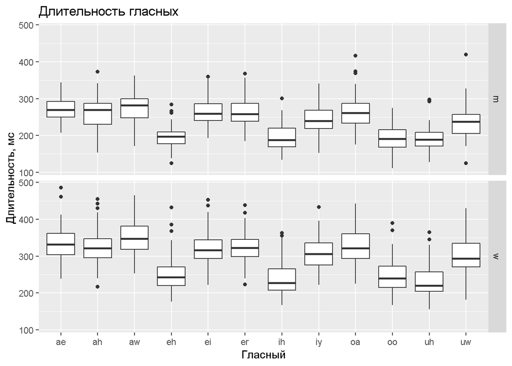

```r
vowels_adults <- subset(vowels, gender == "m" | gender == "w")
ggplot(data = vowels_adults, aes(x=vowel, y=duration)) +
  geom_boxplot() +
  labs(x = 'Гласный', y = 'Длительность, мс', title = 'Длительность гласных') +
  facet_grid(gender ~ .)
```

То же самое, только в скрипичных графиках.

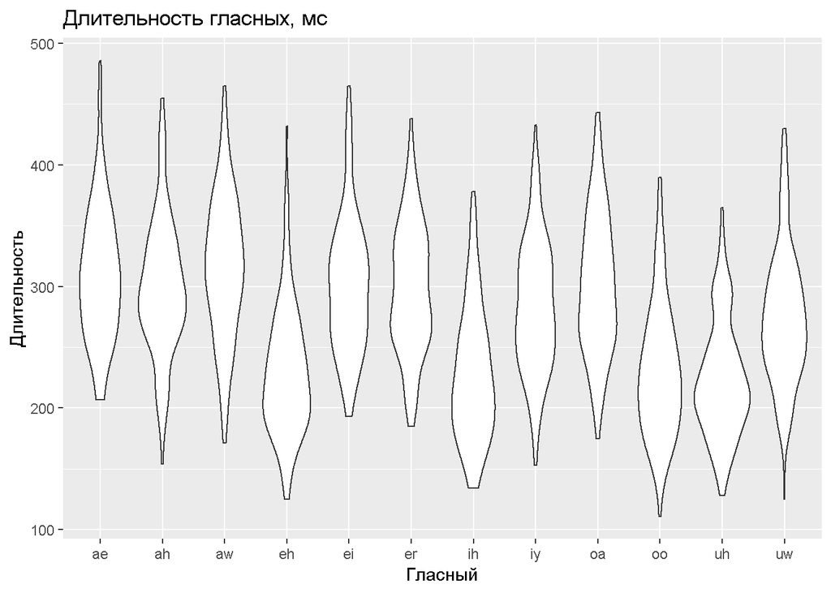

```r
ggplot(data = vowels, aes(x=vowel, y=duration)) + geom_violin() + labs(x = 'Гласный', y = 'Длительность', title = 'Длительность гласных, мс')
```

## Диаграммы рассеяния

Диаграмма рассеяния для всех 1668 гласных. В целом для различения гласных достаточно первой и второй формант, поэтому их значения мы используем в качестве осей координат.

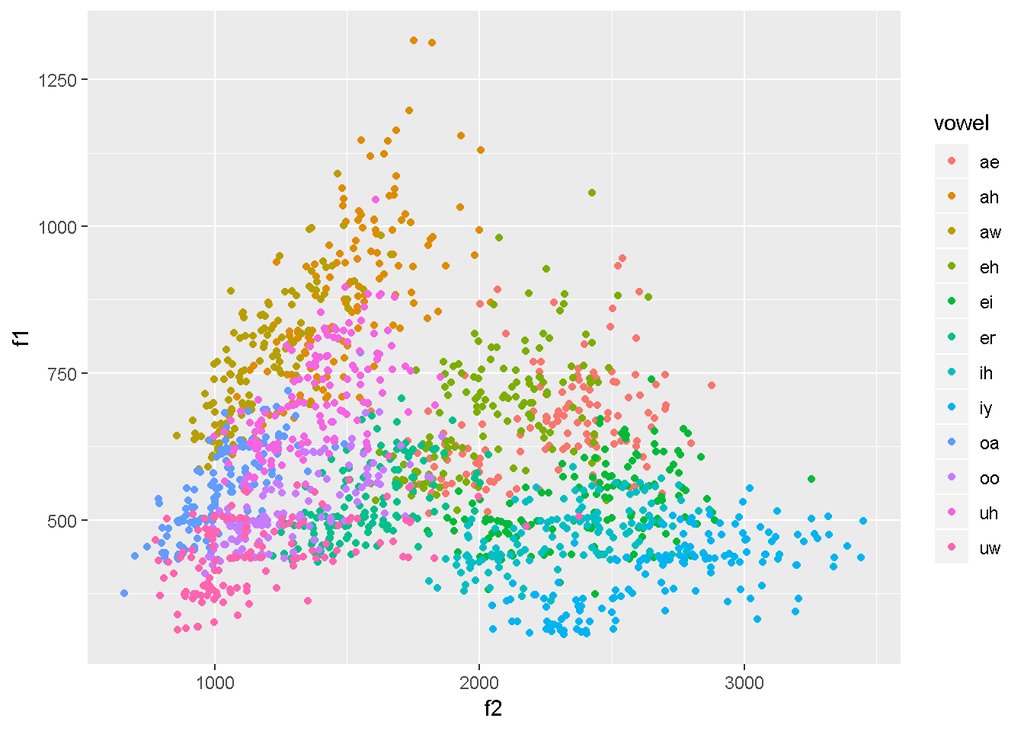

```r
qplot(data = vowels, x=f2, y=f1, color=vowel)
```

На самом деле две первых форманты гласных некоторым образом соответствуют положению языка (чем выше f1, тем сильнее язык опущен вниз; чем выше f2, тем сильнее язык продвинут вперед). Поэтому чтобы получить настоящий треугольник (точнее, трапецоид) гласных, нужно развернуть оси в обратном направлении.

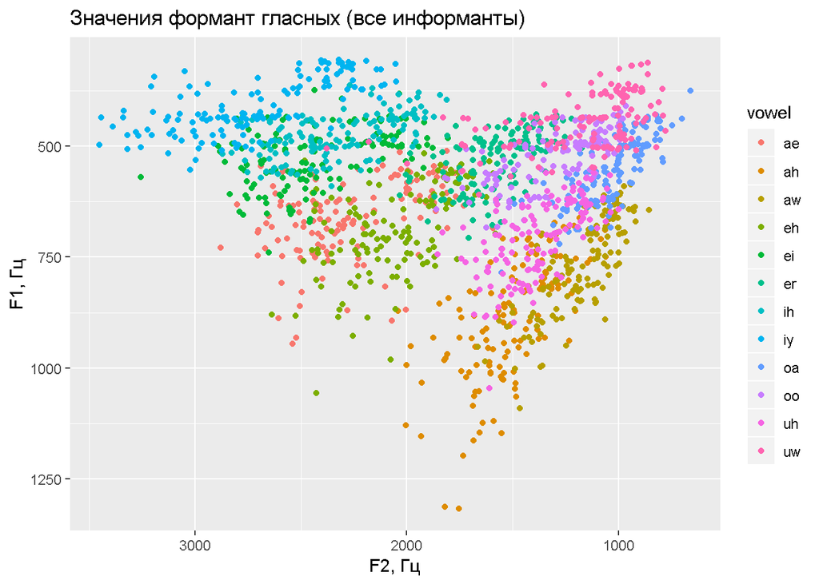

```r
qplot(data = vowels, x=f2, y=f1, color=vowel) + scale_x_reverse() + scale_y_reverse() + labs(x = 'F2, Гц', y = 'F1, Гц', title = 'Значения формант гласных (все информанты)')
```

Конечно, такая “каша” получается из-за того, что на графике вперемешку отображены данные разных полов и возрастов. Построим отдельный график, например, для мужчин.

[figure not shown]

```r
vowels_men <- subset(vowels, gender == "m")
qplot(data = vowels_men, x=f2, y=f1, color=vowel) + scale_x_reverse() + scale_y_reverse() + labs(x = 'F1, Гц', y = 'F2, Гц', title = 'Значения формант гласных (только мужчины)')
```

# Корреляционная матрица

В нашем наборе данных в основном количественные переменные. Самые главные из них - это длительность, а также значения формант. Создадим таблицу, содержащую только эти переменные, и посчитаем корреляции, отбросив отсутствующие значения.

```r
vowels2 <- select(vowels, duration, f0, f1, f2, f3, f4)
vowels_cor <- cor(vowels2, use = "complete.obs")
vowels_cor
```

```
##            duration        f0         f1          f2         f3        f4
## duration 1.00000000 0.3169578  0.1747905  0.07028317 0.09960752 0.1958871
## f0       0.31695780 1.0000000  0.2282953  0.24832239 0.50739681 0.6375085
## f1       0.17479049 0.2282953  1.0000000 -0.14360600 0.10829001 0.2266484
## f2       0.07028317 0.2483224 -0.1436060  1.00000000 0.56198020 0.4669844
## f3       0.09960752 0.5073968  0.1082900  0.56198020 1.00000000 0.6583577
## f4       0.19588707 0.6375085  0.2266484  0.46698444 0.65835770 1.0000000
```

Визуализируем матрицу корреляций.

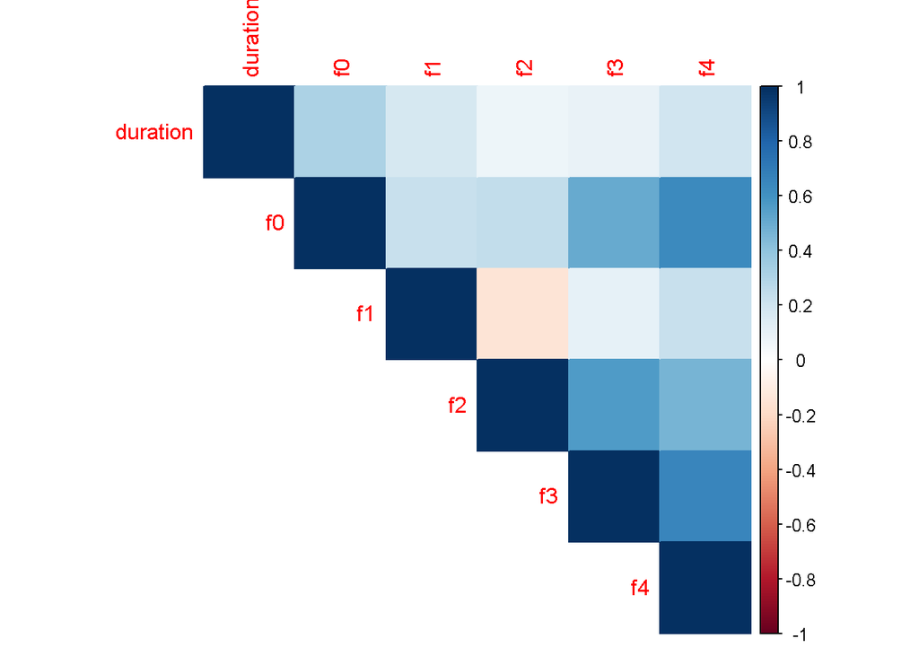

```r
corrplot(vowels_cor, method = "color", type = "upper")
```

# Кластеризация

У нас есть данные в разных единицах измерения: частота формант измеряется в герцах, а длительность гласных - в миллисекундах. Отмасштабируем данные в таблице vowels_stand. Используем только гласные в произношении мужчин. Строки, содержащие отсутствующие значения, отбросим.

```r
vowels3 <- select(vowels_men, name, duration, f0, f1, f2, f3, f4)
vowels3_removed <- drop_na(vowels3)
vowels_stand <- mutate_if(vowels3_removed, is.numeric, ~ as.vector(scale(.)))
vowels_stand_noname <- vowels_stand %>% column_to_rownames(var = 'name')
```

## Кластеризация методом k-means

Предположим, что кластеров пять (например, в русском языке пять гласных фонем).

```r
k_means_vowels_5 <- kmeans(vowels_stand_noname, centers = 5)
k_means_vowels_5
```

[output not shown]

[output cut: 40 more lines]

```
##     2     2     3     2     3     3     3     2     2     3     2     2
## m27uw m29uw m30uw m32uw m33uw m34uw m35uw m36uw m37uw m38uw m39uw m40uw
##     2     3     2     3     3     2     2     2     2     3     3     3
## m41uw m42uw m44uw m47uw m48uw m49uw m50uw
##     3     3     2     2     3     3     2
##
## Within cluster sum of squares by cluster:
## [1] 339.9775 306.1556 271.3959 194.0681 327.3892
##  (between_SS / total_SS =  45.2 %)
##
## Available components:
##
## [1] "cluster"      "centers"      "totss"        "withinss"
## [5] "tot.withinss" "betweenss"    "size"         "iter"
## [9] "ifault"
```

Визуализируем получившиеся кластеры.

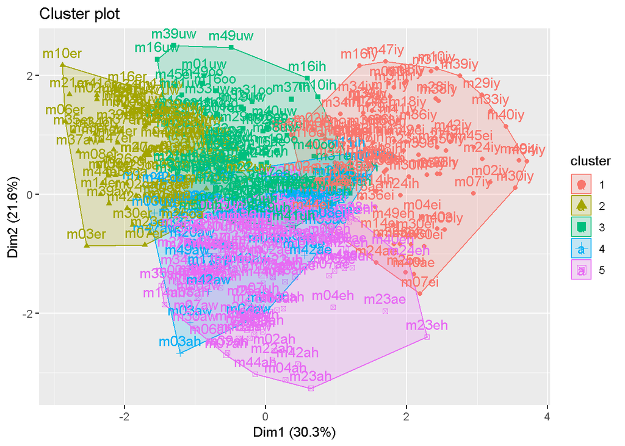

```r
fviz_cluster(object = k_means_vowels_5, data = vowels_stand_noname,
             ellipse.type = 'convex')
```

Но вообще гласных в амерриканском английском 12. Проведем кластеризацию с k=12 и визуализируем кластеры.

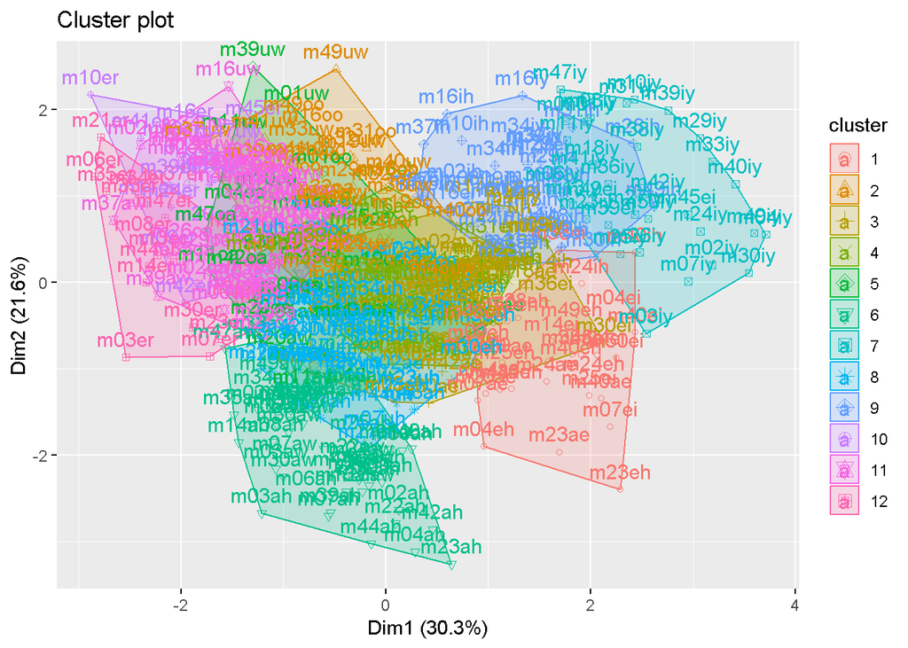

```r
k_means_vowels_12 <- kmeans(vowels_stand_noname, centers = 12)
fviz_cluster(object = k_means_vowels_12, data = vowels_stand_noname,
             ellipse.type = 'convex')
```

## Поиск оптимального числа кластеров

### Метод локтя

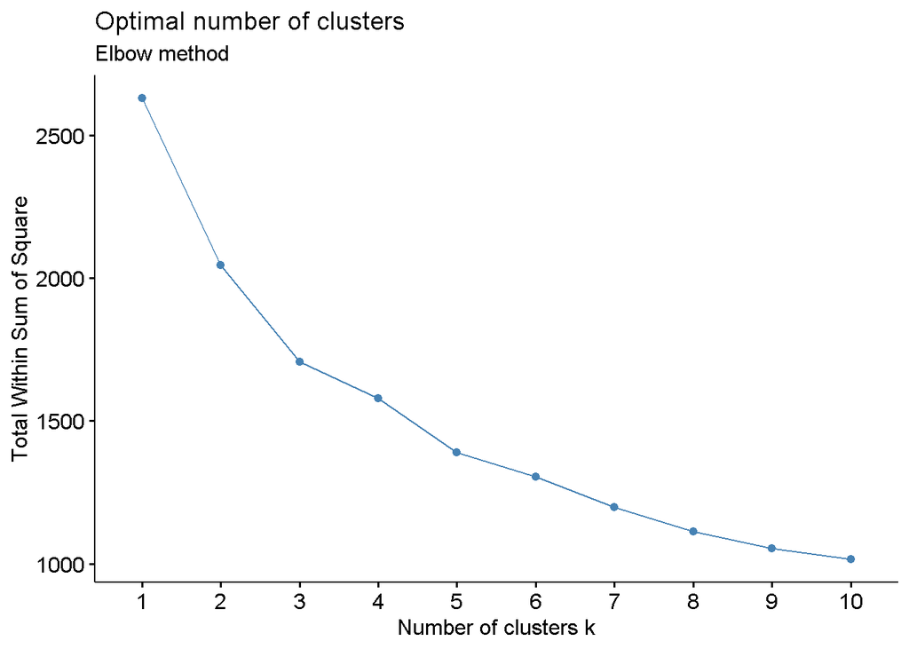

```r
g1 <- fviz_nbclust(vowels_stand_noname, kmeans, method = 'wss') +
  labs(subtitle = 'Elbow method')
g1
```

### Метод силуэта

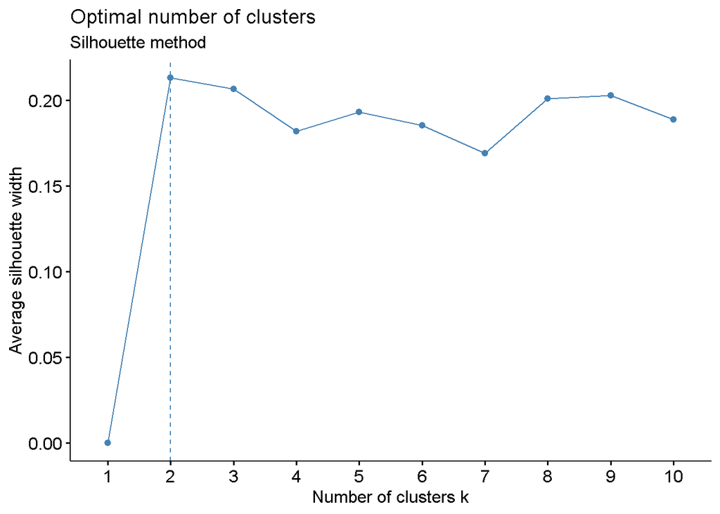

```r
g2 <- fviz_nbclust(vowels_stand_noname, kmeans, method = 'silhouette') +
  labs(subtitle = 'Silhouette method')
g2
```

### Метод Gap statistics

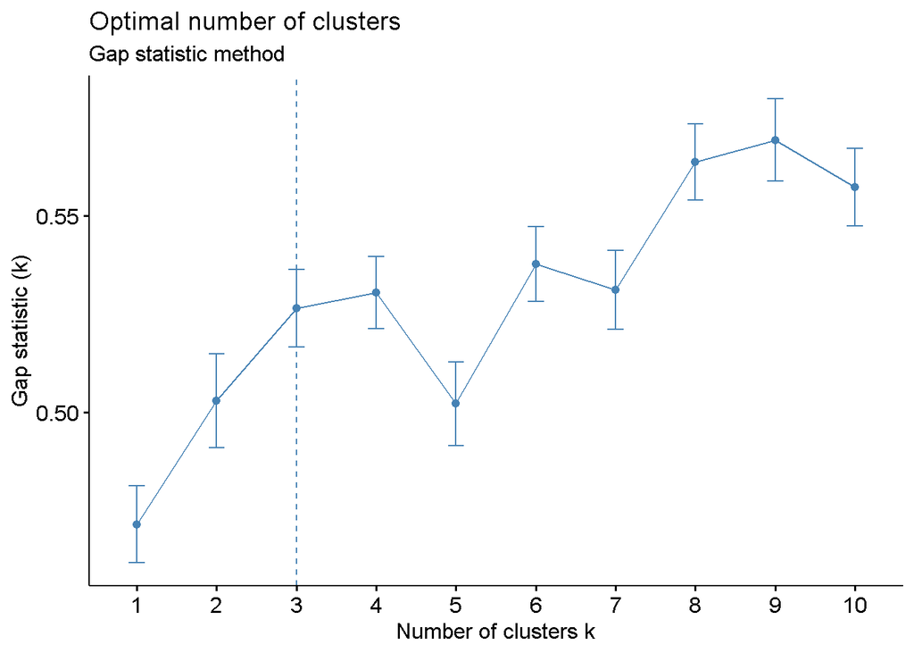

```r
g3 <- fviz_nbclust(vowels_stand_noname, kmeans, method = 'gap_stat') +
  labs(subtitle = 'Gap statistic method')
g3
```

### Красиво расположенные графики

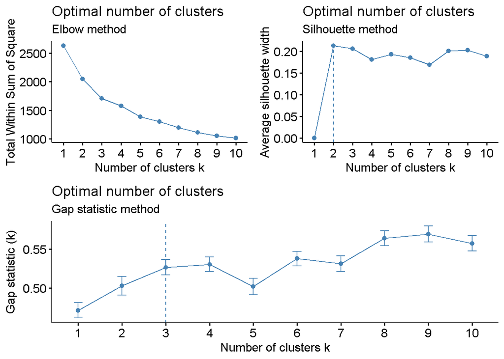

```r
(g1 + g2) / g3
```

Последний метод предлагает делить на три кластера. Это имеет отношение к действительности, потому что на самом деле три “основных” гласных, формирующих “треугольник” - это [i], [u], [a].

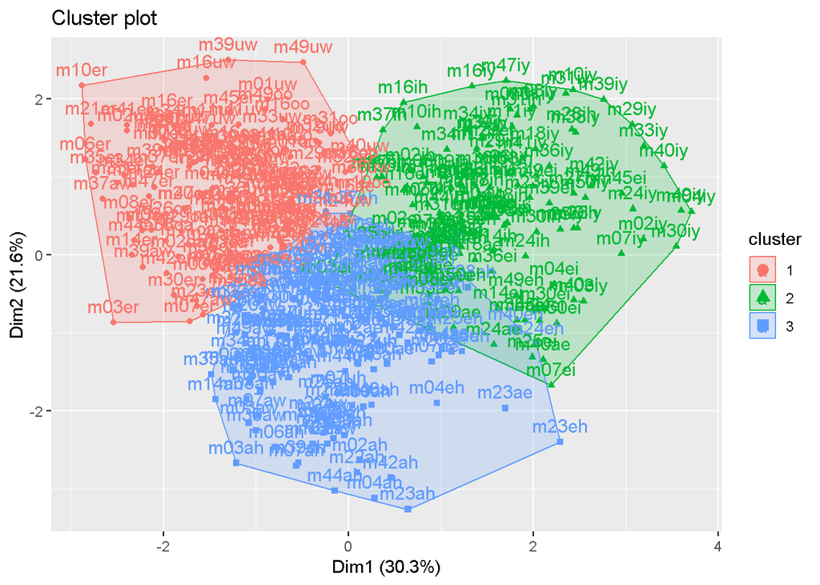

```r
k_means_vowels_3 <- kmeans(vowels_stand_noname, centers = 3)
fviz_cluster(object = k_means_vowels_3, data = vowels_stand_noname,
             ellipse.type = 'convex')
```

Я не смог придумать, как на этом наборе данных сделать иерархическую кластеризацию.

## Метод главных компонент

Упростим задачу компьютеру и выберем только измерения трех “кардинальных” гласных и только в произношении мужчин. Сохраним эти данные (отмасштабироанные) в таблице *vowels_easy*.

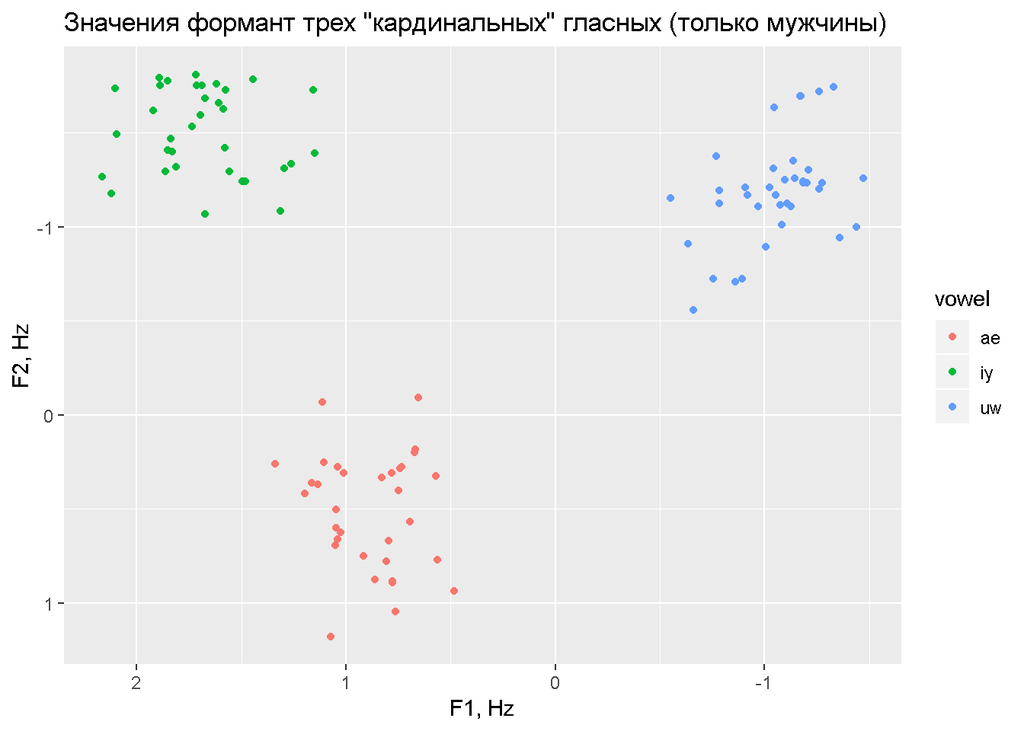

```r
vowels_easy <- select(vowels_men, vowel, name, duration, f0, f1, f2, f3, f4)
vowels_easy <- drop_na(vowels_easy)
vowels_easy <- mutate_if(vowels_easy, is.numeric, ~ as.vector(scale(.)))
vowels_easy <- subset(vowels_easy, vowel == "ae" | vowel == "iy" | vowel == "uw")
qplot(data = vowels_easy, x=f2, y=f1, color=vowel) + scale_x_reverse() + scale_y_reverse() + labs(x = 'F1, Hz', y = 'F2, Hz', title = 'Значения формант трех "кардинальных" гласных (только мужчины)')
```

```r
skim(vowels_easy)
```

```
## Skim summary statistics
##  n obs: 104
##  n variables: 8
##
## Variable type: factor
##  variable missing complete   n n_unique                     top_counts
##      name       0      104 104      104 m01: 1, m01: 1, m01: 1, m02: 1
##     vowel       0      104 104        3  uw: 37, iy: 34, ae: 33, ah: 0
##  ordered
##    FALSE
##    FALSE
##
## Variable type: numeric
##  variable missing complete   n   mean   sd    p0   p25     p50  p75 p100
##  duration       0      104 104  0.25  0.84 -2.13 -0.27  0.2    0.7  3.38
##        f0       0      104 104  0.17  1.05 -1.63 -0.67  0.054  0.87 3.06
##        f1       0      104 104 -0.75  0.92 -1.81 -1.4  -1.17   0.28 1.18
##        f2       0      104 104  0.46  1.19 -1.47 -0.93  0.8    1.51 2.17
##        f3       0      104 104  0.42  0.97 -1.37 -0.3   0.16   1.16 2.99
##        f4       0      104 104  0.028 1.08 -2.19 -0.62  0.0052 0.7  2.65
##      hist
##  ▁▂▆▇▃▂▁▁
##  ▅▇▇▆▅▃▁▁
##  ▅▇▂▁▁▃▂▁
##  ▇▃▁▁▅▆▆▅
##  ▁▆▇▃▃▃▁▁
##  ▂▂▆▇▅▃▂▁
```

Применяем метод главных компонент.

```r
vowels_easy_noname <- select(vowels_easy, name, duration, f0, f1, f2, f3, f4)
vowels_easy_noname <- remove_rownames(vowels_easy_noname)
vowels_easy_noname <- vowels_easy_noname %>% column_to_rownames(var = 'name')
vowels_pca <- prcomp(vowels_easy_noname)
vowels_pca
```

```
## Standard deviations (1, .., p=6):
## [1] 1.5943723 1.1472355 0.9561880 0.8780684 0.7047318 0.3602157
##
## Rotation (n x k) = (6 x 6):
##                  PC1          PC2         PC3         PC4         PC5
## duration -0.09813293  0.360560654 -0.03609096 -0.56821847 -0.73126929
## f0        0.09492746 -0.711504026  0.50245616 -0.48062237 -0.01316139
## f1       -0.03112169  0.546682339  0.52414022 -0.30391077  0.46638492
## f2       -0.70507792  0.004729683 -0.13659466 -0.25979938  0.33418659
## f3       -0.52267337 -0.253873296 -0.28392331 -0.07641502 -0.02096128
## f4       -0.45833156  0.020553234  0.61011617  0.52955942 -0.36801774
##                  PC6
## duration  0.03789966
## f0        0.03342940
## f1       -0.33995624
## f2        0.55227553
## f3       -0.75859727
## f4        0.03738666
```

Визуализируем данные в осях двух первых компонент. Также построим график с проекциями исходных переменных.

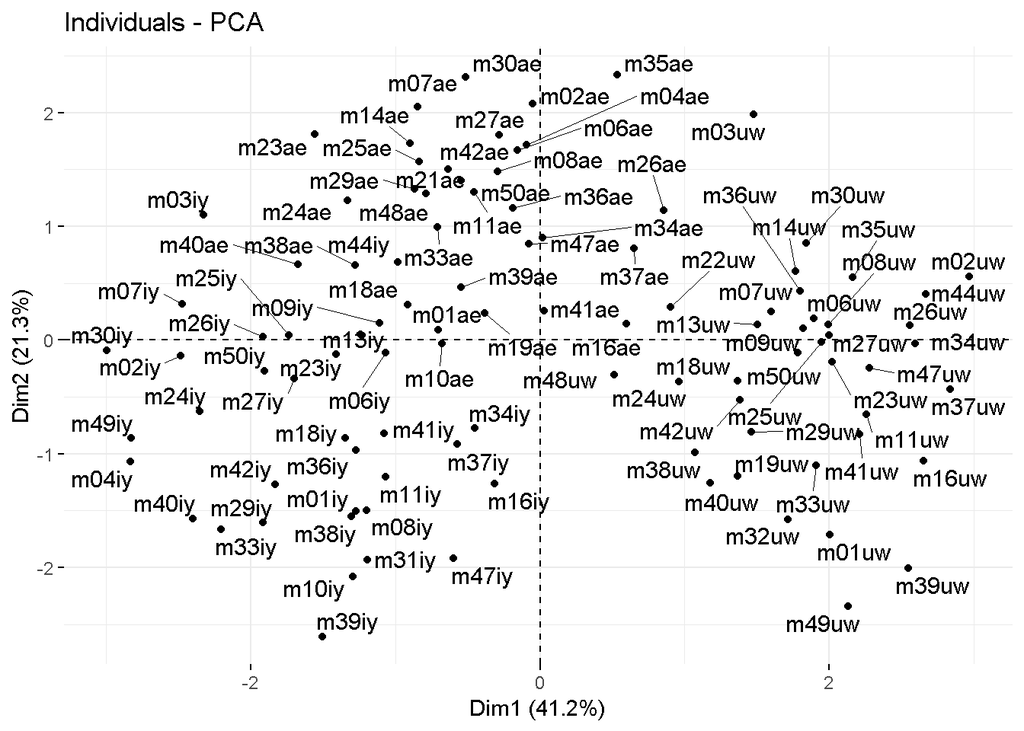

```r
fviz_pca_ind(vowels_pca, repel = TRUE)
```

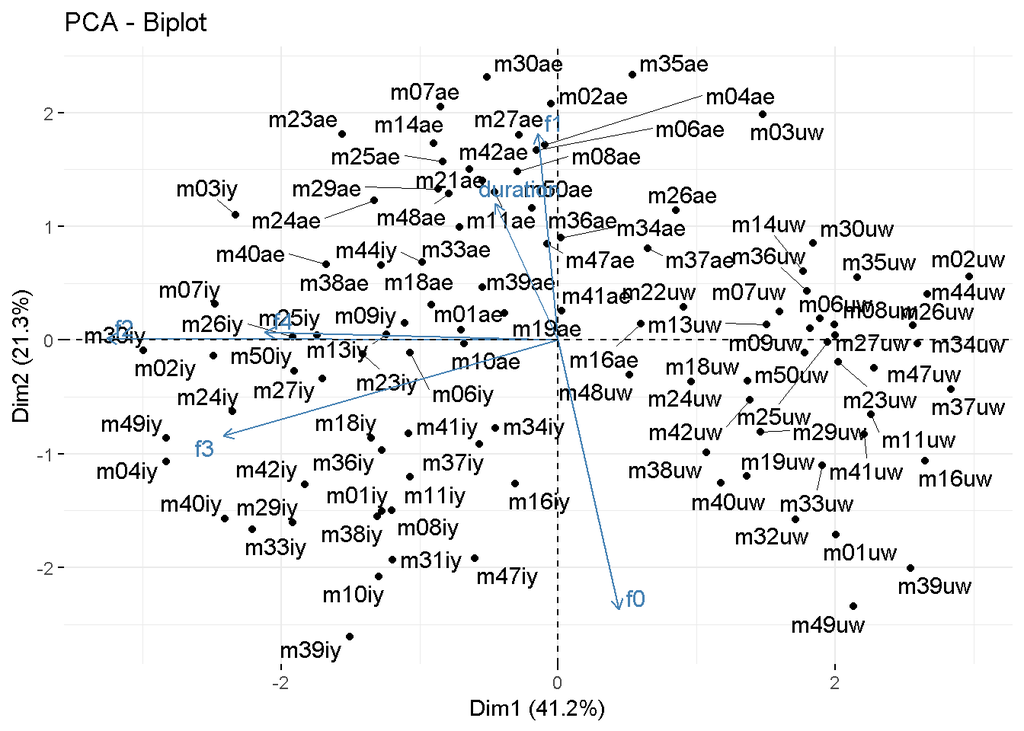

```r
fviz_pca_biplot(vowels_pca, repel = TRUE)
```

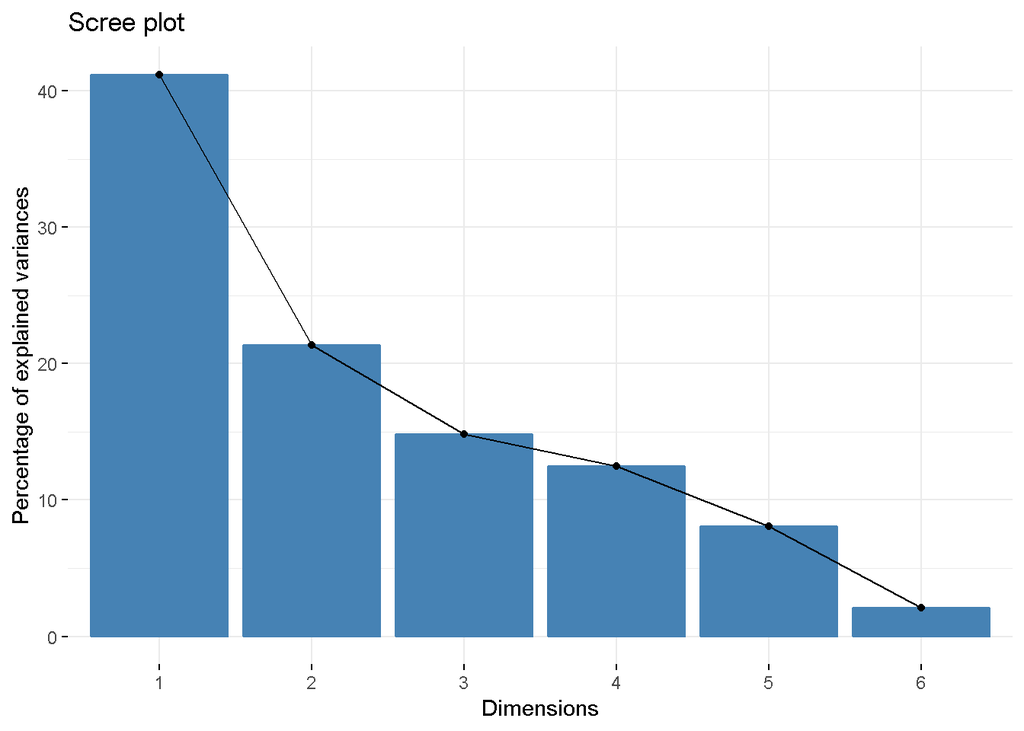

```r
fviz_eig(vowels_pca)
```

Значение второй форманты вносит наибольший вклад в первую главную компоненту.

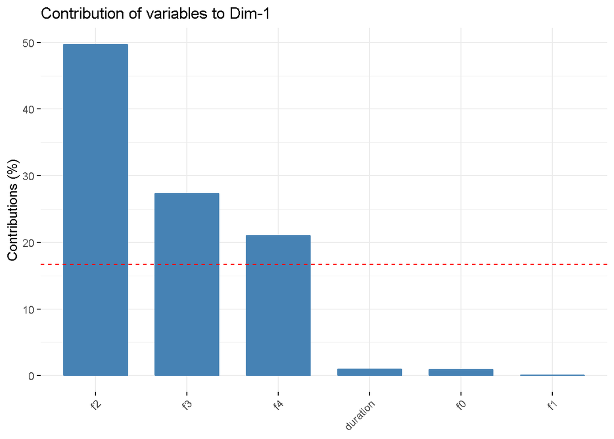

```r
fviz_contrib(vowels_pca, choice = 'var', axes = 1)
```

А вот этот “упрощенный” набор данных получилось очень красиво разделить на кластеры методом k-means.

```r
set.seed(777)
k_means_vowels_easy <- kmeans(vowels_easy_noname, centers = 3)
k_means_vowels_easy
```

```
## K-means clustering with 3 clusters of sizes 37, 34, 33
##
## Cluster means:
##      duration         f0        f1         f2         f3         f4
## 1 -0.01236951  0.4180342 -1.187003 -1.0522565 -0.4475058 -0.5968036
## 2  0.16165531  0.2739147 -1.509623  1.6844963  1.5789765  0.3913578
## 3  0.63689583 -0.2241930  0.510242  0.8863562  0.2026599  0.3556602
##
## Clustering vector:
## m01ae m02ae m04ae m06ae m07ae m08ae m10ae m11ae m14ae m16ae m18ae m19ae
##     3     3     3     3     3     3     3     3     3     3     3     3
## m21ae m23ae m24ae m25ae m26ae m27ae m29ae m30ae m33ae m34ae m35ae m36ae
##     3     3     3     3     3     3     3     3     3     3     3     3
## m37ae m38ae m39ae m40ae m41ae m42ae m47ae m48ae m50ae m01iy m02iy m03iy
##     3     3     3     3     3     3     3     3     3     2     2     2
## m04iy m06iy m07iy m08iy m09iy m10iy m11iy m13iy m16iy m18iy m23iy m24iy
##     2     2     2     2     2     2     2     2     2     2     2     2
## m25iy m26iy m27iy m29iy m30iy m31iy m33iy m34iy m36iy m37iy m38iy m39iy
##     2     2     2     2     2     2     2     2     2     2     2     2
## m40iy m41iy m42iy m44iy m47iy m49iy m50iy m01uw m02uw m03uw m06uw m07uw
##     2     2     2     2     2     2     2     1     1     1     1     1
## m08uw m09uw m11uw m13uw m14uw m16uw m18uw m19uw m22uw m23uw m24uw m25uw
##     1     1     1     1     1     1     1     1     1     1     1     1
## m26uw m27uw m29uw m30uw m32uw m33uw m34uw m35uw m36uw m37uw m38uw m39uw
##     1     1     1     1     1     1     1     1     1     1     1     1
## m40uw m41uw m42uw m44uw m47uw m48uw m49uw m50uw
##     1     1     1     1     1     1     1     1
##
## Within cluster sum of squares by cluster:
## [1] 122.19051  99.92390  79.62335
##  (between_SS / total_SS =  52.5 %)
##
## Available components:
##
## [1] "cluster"      "centers"      "totss"        "withinss"
## [5] "tot.withinss" "betweenss"    "size"         "iter"
## [9] "ifault"
```

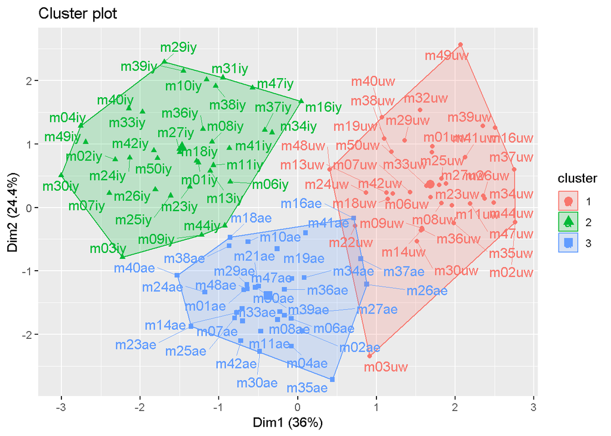

```r
fviz_cluster(object = k_means_vowels_easy, data = vowels_easy_noname,
             ellipse.type = 'convex', repel = TRUE)
```

# Регрессия

**Этот семинар я пропустил. К сожалению, с регрессией пока не получилось разобраться. Но кое-что я попытался сделать.** Построим парную регрессию значения длительности гласного на константу и значение нулевой форманты.

```r
vowels_r <- lm (data = vowels, duration ~ f0)
summary(vowels_r)
```

```
##
## Call:
## lm(formula = duration ~ f0, data = vowels)
##
## Residuals:
##      Min       1Q   Median       3Q      Max
## -150.316  -45.356   -1.201   40.910  204.615
##
## Coefficients:
##              Estimate Std. Error t value Pr(>|t|)
## (Intercept) 196.75804    5.89754   33.36   <2e-16 ***
## f0            0.39545    0.02895   13.66   <2e-16 ***
## ---
## Signif. codes:  0 '***' 0.001 '**' 0.01 '*' 0.05 '.' 0.1 ' ' 1
##
## Residual standard error: 61.19 on 1666 degrees of freedom
## Multiple R-squared:  0.1007, Adjusted R-squared:  0.1002
## F-statistic: 186.6 on 1 and 1666 DF,  p-value: < 2.2e-16
```

Линия регрессии для модели, в которой зависимая переменная - это длительность гласного, а объясняющая - значение нулевой форманты.

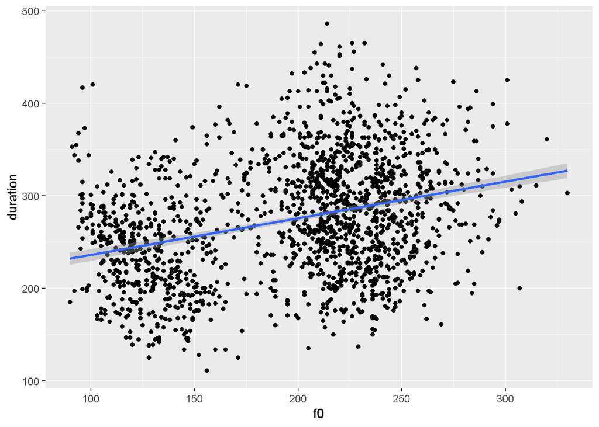

```r
ggplot(data = vowels, aes(x = f0, y = duration)) +
  geom_point() +
  geom_smooth(method = 'lm')
```

Добавим к объясняющим переменным значения первой и второй формант.

```r
vowels_ur <- lm(data = vowels, duration ~ f0 + f1 + f2)
summary(vowels_ur)
```

```
##
## Call:
## lm(formula = duration ~ f0 + f1 + f2, data = vowels)
##
## Residuals:
##      Min       1Q   Median       3Q      Max
## -144.548  -43.875   -1.503   40.550  202.570
##
## Coefficients:
##              Estimate Std. Error t value Pr(>|t|)
## (Intercept) 1.732e+02  8.226e+00  21.055  < 2e-16 ***
## f0          3.522e-01  3.114e-02  11.312  < 2e-16 ***
## f1          4.619e-02  9.791e-03   4.718 2.59e-06 ***
## f2          2.465e-03  2.599e-03   0.948    0.343
## ---
## Signif. codes:  0 '***' 0.001 '**' 0.01 '*' 0.05 '.' 0.1 ' ' 1
##
## Residual standard error: 60.67 on 1654 degrees of freedom
##   (10 observations deleted due to missingness)
## Multiple R-squared:  0.1126, Adjusted R-squared:  0.111
## F-statistic: 69.93 on 3 and 1654 DF,  p-value: < 2.2e-16
```

Построим диагностический график.

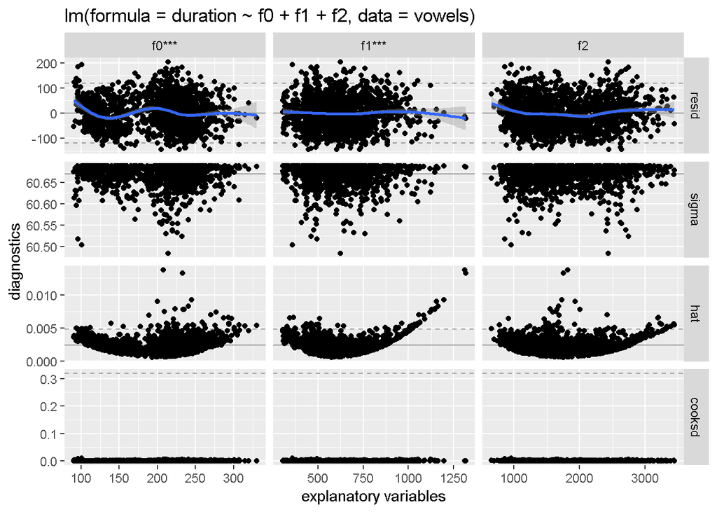

```r
ggnostic (model = vowels_ur)
```

# Классификация

У нас есть мужчины (взрослые мужчины и мальчики) и женщины (взрослые женщины и девочки). Можно ли определить пол человека, если нам известны значения формант и длительности произнесенных ими гласных?

Чтобы сделать классификацию бинарной, в столбце *gender* объединим мальчиков и мужчин в переменную *male*, девочек и женщин в переменную *female*.

```r
vowels_class <- mutate(vowels, gender = fct_collapse(gender, male = c('b', 'm'), female = c('g', 'w')))
vowels_class <- select(vowels_class, gender, f0, f1, f2, f3, f4, duration, vowel)
vowels_class <- drop_na(vowels_class)
```

Разделим выборку на две части: обучающую и тестовую.

```r
set.seed(777)
train_rows <- createDataPartition(vowels_class$gender, p = 0.8, list = FALSE)
vowels_train <- vowels_class[train_rows, ]
vowels_test <- vowels_class[-train_rows, ]
```

## Модель с логистической регрессией

```r
vowels_lmodel_glm <- glm(data = vowels_train, gender ~ f0 + f1 + f2 + f3 + f4 + duration, family = binomial(link = 'logit'))
summary(vowels_lmodel_glm)
```

```
##
## Call:
## glm(formula = gender ~ f0 + f1 + f2 + f3 + f4 + duration, family = binomial(link = "logit"),
##     data = vowels_train)
##
## Deviance Residuals:
##     Min       1Q   Median       3Q      Max
## -2.5713  -0.5479  -0.2598   0.8790   1.6790
##
## Coefficients:
##               Estimate Std. Error z value Pr(>|z|)
## (Intercept) -9.878e+00  8.774e-01 -11.258  < 2e-16 ***
## f0           2.219e-02  2.172e-03  10.217  < 2e-16 ***
## f1           2.618e-04  4.970e-04   0.527   0.5984
## f2          -1.306e-04  1.574e-04  -0.830   0.4066
## f3           1.494e-05  2.510e-04   0.060   0.9525
## f4           7.976e-04  2.527e-04   3.156   0.0016 **
## duration     7.880e-03  1.244e-03   6.334 2.39e-10 ***
## ---
## Signif. codes:  0 '***' 0.001 '**' 0.01 '*' 0.05 '.' 0.1 ' ' 1
##
## (Dispersion parameter for binomial family taken to be 1)
##
##     Null deviance: 1538.4  on 1109  degrees of freedom
## Residual deviance: 1092.2  on 1103  degrees of freedom
## AIC: 1106.2
##
## Number of Fisher Scoring iterations: 5
```

Найдем предельные эффекты и визуализируем эффект f0.

```r
vowels_margins <- margins(vowels_lmodel_glm)
summary(vowels_margins)
```

```
##    factor     AME     SE       z      p   lower  upper
##  duration  0.0013 0.0002  6.7561 0.0000  0.0009 0.0016
##        f0  0.0036 0.0003 12.3059 0.0000  0.0030 0.0042
##        f1  0.0000 0.0001  0.5269 0.5982 -0.0001 0.0002
##        f2 -0.0000 0.0000 -0.8308 0.4061 -0.0001 0.0000
##        f3  0.0000 0.0000  0.0596 0.9525 -0.0001 0.0001
##        f4  0.0001 0.0000  3.2041 0.0014  0.0001 0.0002
```

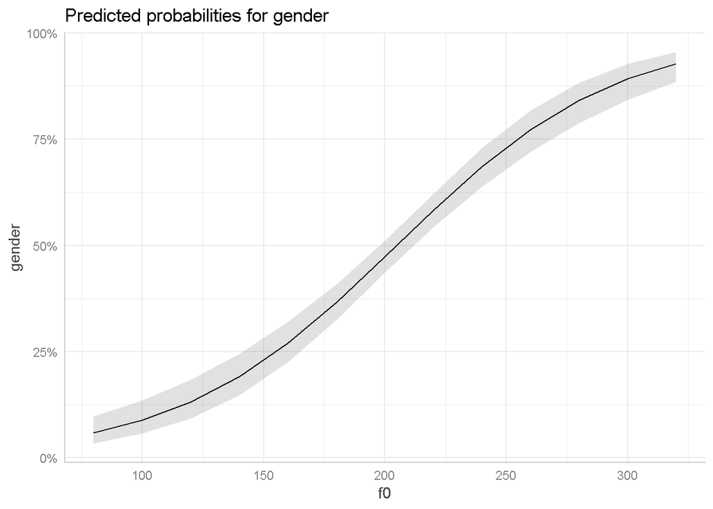

```r
pred_vowels_vis <- ggpredict(vowels_lmodel_glm, terms = 'f0')
plot(pred_vowels_vis)
```

Оценка модели с помощью пакета caret.

```r
vowels_lmodel <- train(data = vowels_train, gender ~ f0 + f1 + f2 + f3 + f4 + duration, family = binomial(link = 'logit'), method = 'glm')
summary(vowels_lmodel)
```

```
##
## Call:
## NULL
##
## Deviance Residuals:
##     Min       1Q   Median       3Q      Max
## -2.5713  -0.5479  -0.2598   0.8790   1.6790
##
## Coefficients:
##               Estimate Std. Error z value Pr(>|z|)
## (Intercept) -9.878e+00  8.774e-01 -11.258  < 2e-16 ***
## f0           2.219e-02  2.172e-03  10.217  < 2e-16 ***
## f1           2.618e-04  4.970e-04   0.527   0.5984
## f2          -1.306e-04  1.574e-04  -0.830   0.4066
## f3           1.494e-05  2.510e-04   0.060   0.9525
## f4           7.976e-04  2.527e-04   3.156   0.0016 **
## duration     7.880e-03  1.244e-03   6.334 2.39e-10 ***
## ---
## Signif. codes:  0 '***' 0.001 '**' 0.01 '*' 0.05 '.' 0.1 ' ' 1
##
## (Dispersion parameter for binomial family taken to be 1)
##
##     Null deviance: 1538.4  on 1109  degrees of freedom
## Residual deviance: 1092.2  on 1103  degrees of freedom
## AIC: 1106.2
##
## Number of Fisher Scoring iterations: 5
```

Строим прогнозы для тестовых данных.

```r
vowels_pred <- predict(vowels_lmodel, newdata = vowels_test)
head(vowels_pred)
```

```
## [1] male   male   male   male   male   female
## Levels: male female
```

```r
vowels_prob <- predict(vowels_lmodel, newdata = vowels_test, type = 'prob')
head(vowels_prob)
```

```
##         male     female
## 9  0.8142611 0.18573895
## 13 0.9307028 0.06929719
## 24 0.9448069 0.05519308
## 27 0.9240745 0.07592553
## 33 0.9128514 0.08714857
## 46 0.2771754 0.72282457
```

Матрица ошибок. Точность предсказания составила 75%.

```r
confusionMatrix(data = vowels_pred, reference = vowels_test$gender)
```

```
## Confusion Matrix and Statistics
##
##           Reference
## Prediction male female
##     male     87     14
##     female   54    122
##
##                Accuracy : 0.7545
##                  95% CI : (0.6995, 0.804)
##     No Information Rate : 0.509
##     P-Value [Acc > NIR] : < 2.2e-16
##
##                   Kappa : 0.5114
##  Mcnemar's Test P-Value : 2.251e-06
##
##             Sensitivity : 0.6170
##             Specificity : 0.8971
##          Pos Pred Value : 0.8614
##          Neg Pred Value : 0.6932
##              Prevalence : 0.5090
##          Detection Rate : 0.3141
##    Detection Prevalence : 0.3646
##       Balanced Accuracy : 0.7570
##
##        'Positive' Class : male
##
```

Создадим таблицу с данными предсказания, а затем построим ROC-кривую.

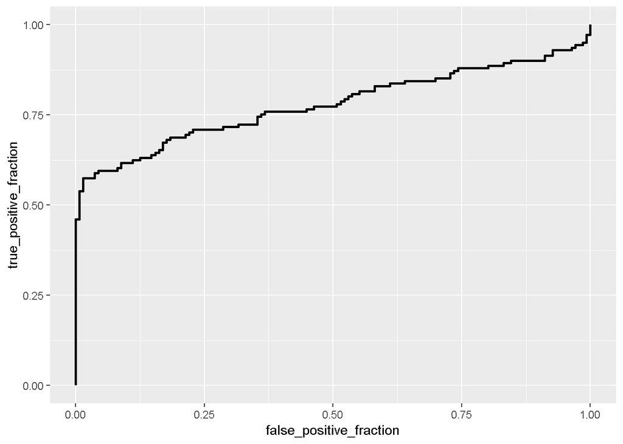

```r
vowels_test_set <- data.frame(male = vowels_prob$male,
                        female = vowels_prob$female,
                        pred = vowels_pred,
                        obs = vowels_test$gender)
ggplot(vowels_test_set, aes(d = obs, m = male)) +
  geom_roc(n.cuts = 0)
```

## “Быстрое и стройное дерево”

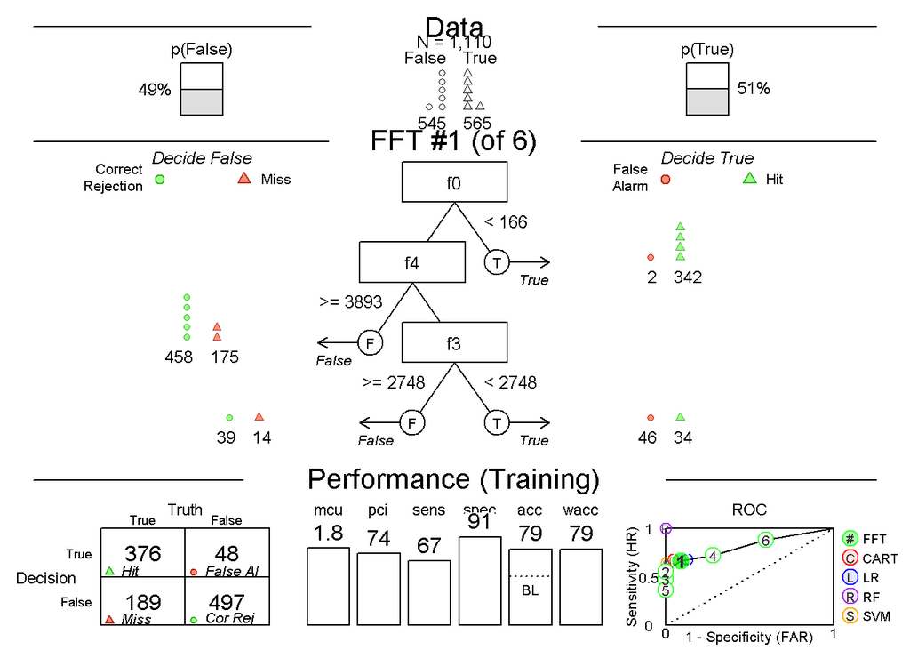

```r
vowels_train2 <- mutate(vowels_train, ybin = ifelse(gender == 'male', 1, 0))
fftree_model <- FFTrees(formula = ybin ~ f0 + f1 + f2 + f3 + f4 + duration,
                     data = vowels_train2)
plot(fftree_model)
```

## “Случайный лес”

```r
ranger_model <- train(gender ~ f0 + f1 + f2 + f3 + f4 + duration, data = vowels_train,
                      method = 'ranger',
                      na.action = na.omit,
                      importance = 'impurity')
```

Попробуем определить важность переменных.

```r
ranger_import <- varImp(ranger_model)
ranger_import
```

```
## ranger variable importance
##
##          Overall
## f0       100.000
## f4        23.003
## duration   9.849
## f3         5.445
## f1         3.833
## f2         0.000
```

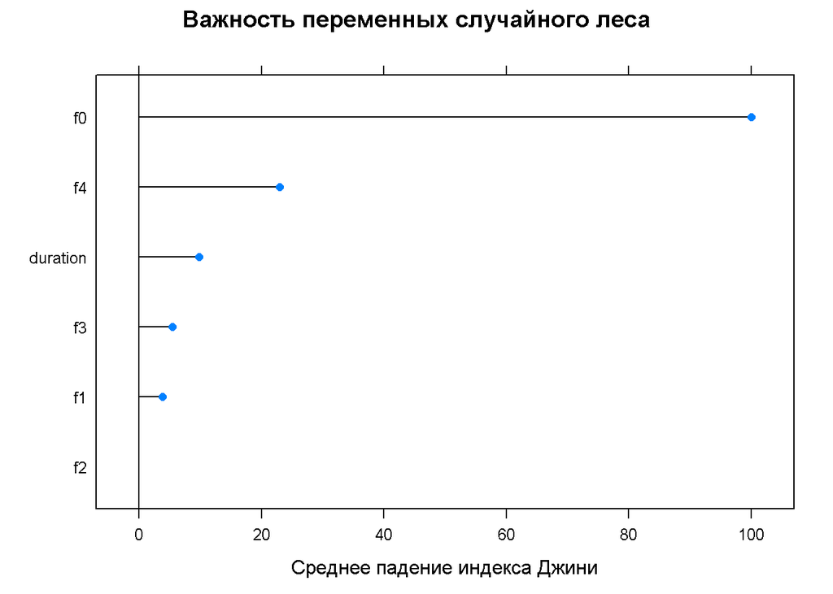

```r
plot(ranger_import,
    main = 'Важность переменных случайного леса',
    xlab = 'Среднее падение индекса Джини')
```

Наконец, строим прогноз на основе полученной модели. Точность оказалась на 4% выше, чем при использовании модели с логистической регрессией, и достигла 79%.

```r
vowels_ranger <- mutate(vowels_test,
  yhat = predict(ranger_model, vowels_test, na.action = na.pass))
confusionMatrix(vowels_ranger$yhat, vowels_ranger$gender)
```

```
## Confusion Matrix and Statistics
##
##           Reference
## Prediction male female
##     male     97     14
##     female   44    122
##
##                Accuracy : 0.7906
##                  95% CI : (0.7379, 0.837)
##     No Information Rate : 0.509
##     P-Value [Acc > NIR] : < 2.2e-16
##
##                   Kappa : 0.5827
##  Mcnemar's Test P-Value : 0.0001402
##
##             Sensitivity : 0.6879
##             Specificity : 0.8971
##          Pos Pred Value : 0.8739
##          Neg Pred Value : 0.7349
##              Prevalence : 0.5090
##          Detection Rate : 0.3502
##    Detection Prevalence : 0.4007
##       Balanced Accuracy : 0.7925
##
##        'Positive' Class : male
##
```

# Конец

[figure not shown]

Спасибо